# MA22004

26/11/2020

## Announcements

### Reminders

- It is week 8! You should have read the remainder of §6 of the notes on **Perusall**.
- Class test 2 was yesterday.

## Linear Regression (what is it?)

- Assumes relationship between two variables \(X\) and \(Y\) can be modeled by a straight line
- Perfect linear relationship: we would know the exact value of \(Y\) just by knowing the exact value of \(X\)

\[y = \beta_0 + \beta_1 x\]

## Palmer penguins (Gentoo)

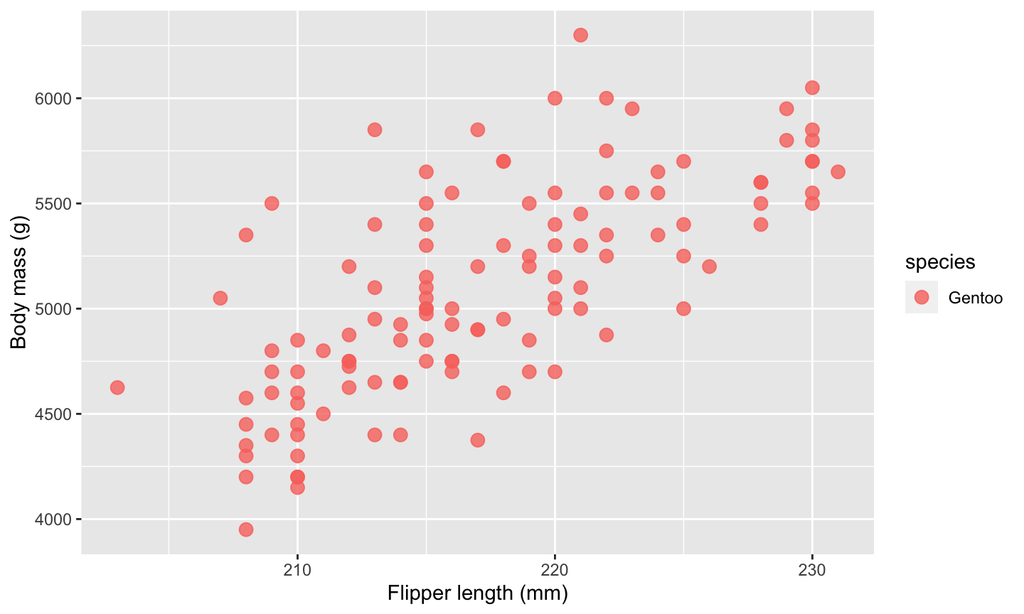

## Fitting a line by eye

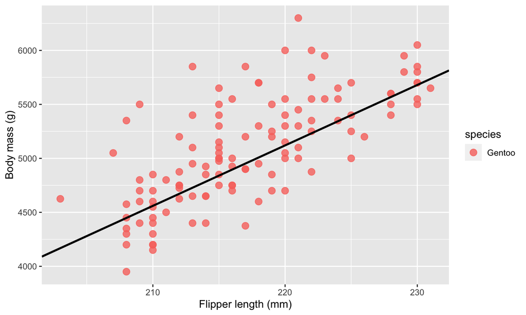

## Residuals (every observation has a friend)

Data = Fit + Residual

One goal in regression is to pick the linear model to minimize residuals.

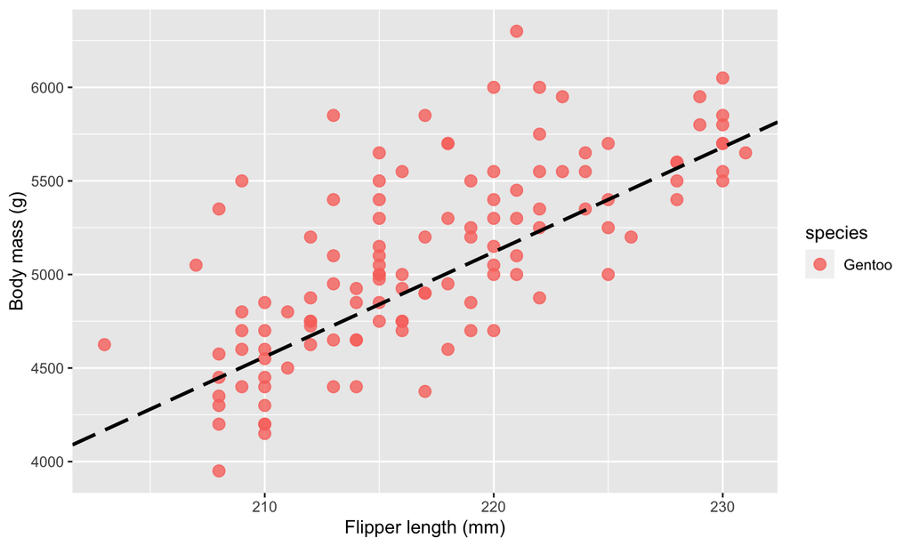

## Correlation

Correlation describes the strength of a linear relationship.

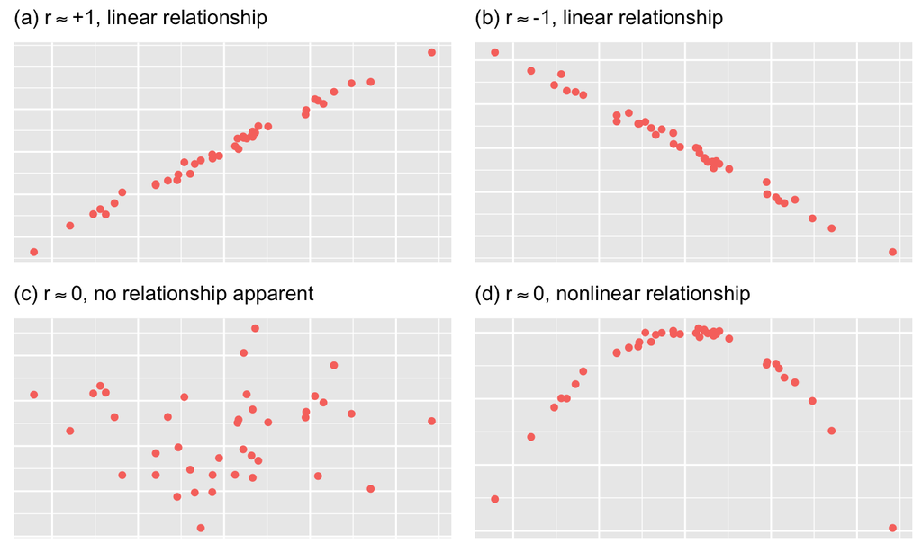

## Finding “best fit”

We want a line that minimizes the residuals.

- Choose the line that minimizes the sum of the squared residuals \[\epsilon_1^2 + \epsilon_2^2 + \dots \epsilon_m^2\]
- Commonly referred to as **least squares line**

## Conditions for linear regression

For fitting a least squares line we focus on three requirements:

- **Linearity**: data should show linear trend
- **Nearly normal residuals**: (usually fails due to outliers)
- **Constant variability**: variability of points around least squares line

## Conditions for linear regression (in pictures)

For fitting a least squares line we focus on three requirements:

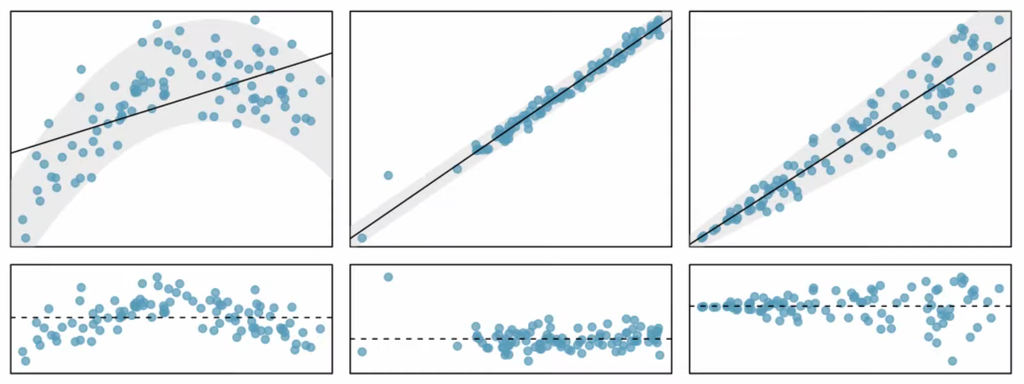

## Finding the least squares line

**Least squares estimates** for \(\widehat{\beta}_1\) and \(\widehat{\beta}_0\) are given by \[ \widehat{\beta}_1 = \frac{\sum_{i=1}^m (X_i - \overline{X})(Y_i - \overline{Y})}{\sum_{i=1}^m (X_i - \overline{X})^2} \] \[ \widehat{\beta}_0 = \overline{Y} - \widehat{\beta}_1 \overline{X} \]

```r
xbar <- mean(gentoo$flipper_length_mm)
ybar <- mean(gentoo$body_mass_g)
sxy <- cov(gentoo$flipper_length_mm, gentoo$body_mass_g)
sxx <- var(gentoo$flipper_length_mm)

b1 <- sxy/sxx
b0 <- ybar - b1*xbar
```

## Least squares fit

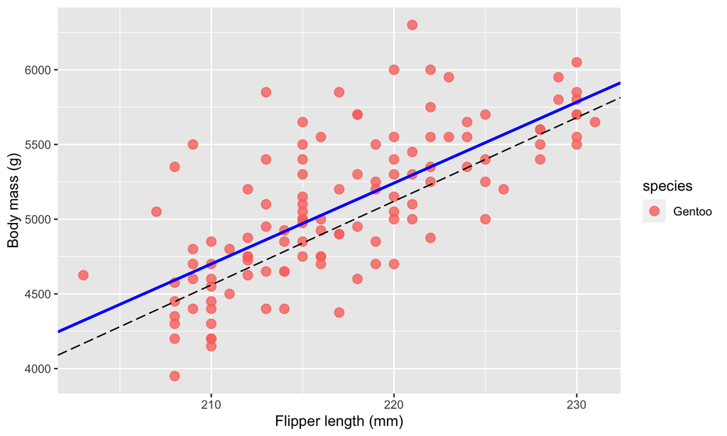

## What do these numbers mean?

- **SLOPE**: For each additional 10 mm flipper length, we would expect the penguin to weigh 541.7 g **more**.
- **INTERCEPT**: -6674.20 g describes the average weight if a penguin had flipper length 0…

Extrapolation can be treacherous (here there are no observations near zero).

## Summary

Today we discussed least squares regression.